# task_1

### Пункт 3: Визуализация данных отдельных показателей

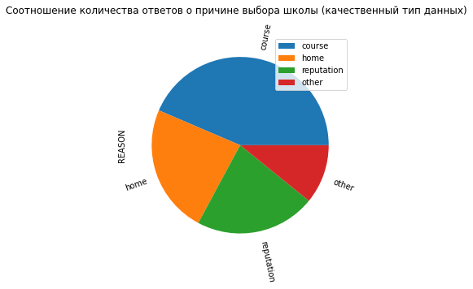

```python
#Соотношение количества ответов о причине выбора школы (качественный тип данных)
df = pd.DataFrame(data=students["REASON"].value_counts())
plot = df.plot.pie(subplots=True, figsize=(5, 5), rotatelabels=True, title = 'Соотношение количества ответов о причине выбора школы (качественный тип данных)')
```

По данной круговой диаграмме можно сказать, что больше всего учеников шли в свою школу из-за предпочтений в курсах.

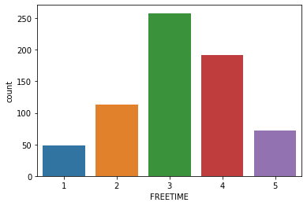

```python
#Количество свободного времени у учеников (качественный)
sns.countplot(x = "FREETIME", data = students)
```

По данному графику видно, что у большинства учеников среднее количество свободного времени.

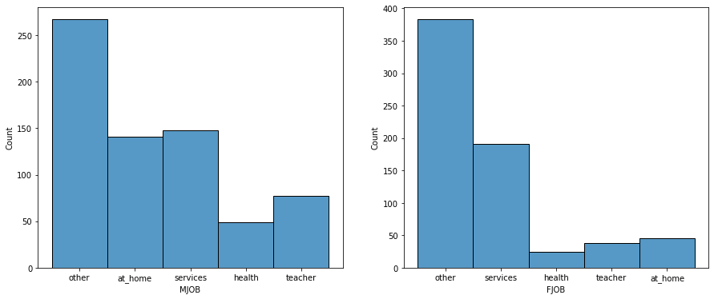

```python
#Работы родителей учеников (качественный)
_, axes = plt.subplots(nrows=1, ncols=2, figsize=(15, 6))

sns.histplot(x="MJOB", data=students, ax=axes[0])
sns.histplot(x="FJOB", data=students, ax=axes[1]);
```

Большее число отцов и матерей работают на работах, не представленных в списке

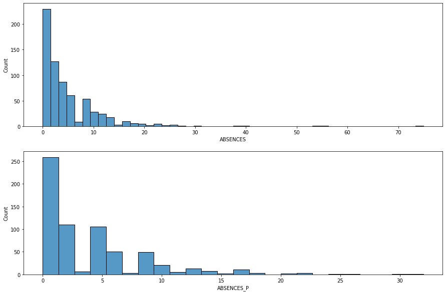

```python
#количество пропусков по занятиям (количественный)
_, axes = plt.subplots(nrows=2, ncols=1, figsize=(15, 10))

sns.histplot(x="ABSENCES", data=students, ax=axes[0])
sns.histplot(x="ABSENCES_P", data=students, ax=axes[1]);
```

У большинства учеников от 0 до 5 пропусков

```python
average_grade = []
average_grade.append(students["G1M"].mean())
average_grade.append(students["G2M"].mean())
average_grade.append(students["G3M"].mean())
average_grade.append(students["G1P"].mean())
average_grade.append(students["G2P"].mean())
average_grade.append(students["G3P"].mean())
average_grade
```

```
[10.879606879606879,
 10.678132678132679,
 10.343980343980345,
 11.397260273972602,
 11.56468797564688,
 11.898021308980214]
```

[output not shown]

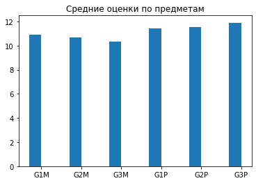

```python
#Средние оценки по предметам за 3 года (количественный)
cat_par = ["G1M", "G2M", "G3M", "G1P", "G2P", "G3P"]
width = 0.3
x = np.arange(len(cat_par))
fig, ax = plt.subplots()
rects1 = ax.bar(x - width/2, average_grade, width)

ax.set_title('Средние оценки по предметам')
ax.set_xticks(x)
ax.set_xticklabels(cat_par)
```

В среднем по предметам оценки от 10 до 12, а также средние оценки по португальскому выше, чем по математике. Оценки по математике убывают, а по португальскому возрастают.

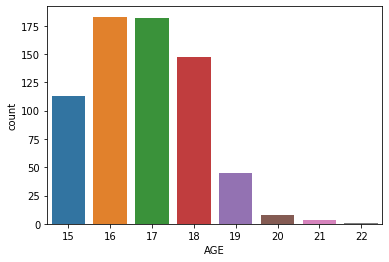

```python
#Количество студентов определенного возраста (количественный)
sns.countplot(x = "AGE", data = students)
```

Больше всего учеников в возрасте 16-17 лет

### Пункт 4: Группировка объектов

В качестве атрибута группировки выберем атрибут reason, отражающий причины постуления учеников в их школу.

```python
groups = students.groupby('REASON')
print("Групп: {0}".format(len(groups)))
for reason, g in groups:
    print(reason)
```

```
Групп: 4
course
home
other
reputation
```

Вычислим средние значения по количественным показателям для каждой группы:

```python
for (reason, g) in groups:
    print("Reason: {0:10} mean age:{1:5.2f} mean abs_m:{2:5.2f} mean abs_p:{3:5.2f}".format(reason, g["AGE"].mean(), g["ABSENCES"].mean(), g["ABSENCES_P"].mean()))
```

```
Reason: course     mean age:16.82 mean abs_m: 3.83 mean abs_p: 3.44
Reason: home       mean age:16.81 mean abs_m: 6.22 mean abs_p: 4.49
Reason: other      mean age:16.77 mean abs_m: 4.04 mean abs_p: 2.78
Reason: reputation mean age:16.79 mean abs_m: 5.90 mean abs_p: 3.81
```

```python
for (reason, g) in groups:
    print("Reason: {0:10} mean G1M:{1:5.2f} mean G2M:{2:5.2f} mean G3M:{3:5.2f} mean G1P:{4:5.2f} mean G2P: {5:5.2f} mean G3P:{6:5.2f}".format(reason, g["G1M"].mean(), g["G2M"].mean(), g["G3M"].mean(), g["G1P"].mean(), g["G2P"].mean(), g["G3P"].mean()))
```

```
Reason: course     mean G1M:10.59 mean G2M:10.15 mean G3M: 9.74 mean G1P:10.99 mean G2P: 11.15 mean G3P:11.54
Reason: home       mean G1M:10.75 mean G2M:10.67 mean G3M:10.15 mean G1P:11.63 mean G2P: 11.75 mean G3P:12.15
Reason: other      mean G1M:10.83 mean G2M:11.22 mean G3M:11.17 mean G1P:10.69 mean G2P: 10.78 mean G3P:10.69
Reason: reputation mean G1M:11.46 mean G2M:11.26 mean G3M:11.14 mean G1P:12.31 mean G2P: 12.59 mean G3P:12.94
```

Наибольшую разницу в средних значениях имеют параметры ABSENCES и ABSENCES_P, отражающие количество пропусков занятий. Построим для них диаграммы размаха по группам:

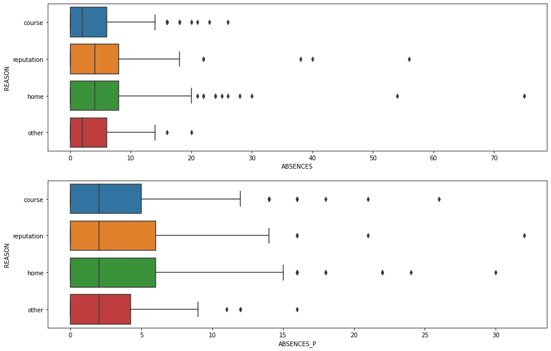

```python
# создаем диаграммы размаха показателя "ABSENCES" и "ABSENCES_P" по группам "REASON"
_, axes = plt.subplots(nrows=2, ncols=1, figsize=(15, 10))
sns.boxplot(x = "ABSENCES", y = "REASON", data = students, ax = axes[0])
sns.boxplot(x = "ABSENCES_P", y = "REASON", data = students, ax = axes[1])
```

Найдем для каждого качественного показателя моду внутри каждой из групп и найдем атрибут с наибольшей разницей по частотам:

```python
for (reason, g) in groups:
    print("Reason: {0:10} FAMREL:{1} FREETIME:{2} GOOUT:{3} DALC:{4} WALC:{5}".format(reason, stat.mode(g["FAMREL"]), stat.mode(g["FREETIME"]), stat.mode(g["GOOUT"]),stat.mode(g["DALC"]),stat.mode(g["WALC"])))
```

```
Reason: course     FAMREL:4 FREETIME:3 GOOUT:3 DALC:1 WALC:1
Reason: home       FAMREL:4 FREETIME:3 GOOUT:3 DALC:1 WALC:1
Reason: other      FAMREL:4 FREETIME:3 GOOUT:3 DALC:1 WALC:1
Reason: reputation FAMREL:4 FREETIME:3 GOOUT:3 DALC:1 WALC:1
```

```python
for (reason, g) in groups:
    print("Reason: {0:10} MJOB:{1} FJOB:{2} MEDU:{3} FEDU:{4} guardian:{5} traveltime:{6} studytime:{7}".format(reason, stat.mode(g["MJOB"]), stat.mode(g["FJOB"]), stat.mode(g["MEDU"]), stat.mode(g["FEDU"]), stat.mode(g["GUARDIAN"]), stat.mode(g["TRAVELTIME"]), stat.mode(g["STUDYTIME"])))
```

```
Reason: course     MJOB:other FJOB:other MEDU:2 FEDU:2 guardian:mother traveltime:1 studytime:2
Reason: home       MJOB:other FJOB:other MEDU:3 FEDU:2 guardian:mother traveltime:1 studytime:2
Reason: other      MJOB:other FJOB:other MEDU:4 FEDU:1 guardian:mother traveltime:1 studytime:1
Reason: reputation MJOB:other FJOB:other MEDU:4 FEDU:2 guardian:mother traveltime:1 studytime:2
```

По полученным результатам видно, что наибольшую разницу по частотам имеет атрибут MEDU